# Examen 1 - Ejercicio 1

*175904 - Jorge III Altamirano Astorga*

*177508 - Uriel Miranda Miñón*

Datos de [Enron](https://archive.ics.uci.edu/ml/datasets/Bag+of+Words)

## Carga de datos

```r
vocab <- read_csv("enron/vocab.enron.txt", col_names = "word")
vocab <- vocab %>%
  rowid_to_column("word_id")
vocab
```

| word_id | word |
| --- | --- |
| 1 | aaa |
| 2 | aaas |
| 3 | aactive |
| 4 | aadvantage |
| 5 | aaker |
| 6 | aap |
| 7 | aapg |
| 8 | aaron |
| 9 | aarp |
| 10 | aas |

[output cut: 9990 more lines]

```r
enron <- read_table2("enron/docword.enron.txt",
                  col_names = c("doc_id", "word_id", "n"),
                  col_types = "iii",
                  progress = F,
                  skip = 3)
enron[1:5,]
```

| doc_id | word_id | n |
| --- | --- | --- |
| 1 | 118 | 1 |
| 1 | 285 | 1 |
| 1 | 1229 | 1 |
| 1 | 1688 | 1 |
| 1 | 2068 | 1 |

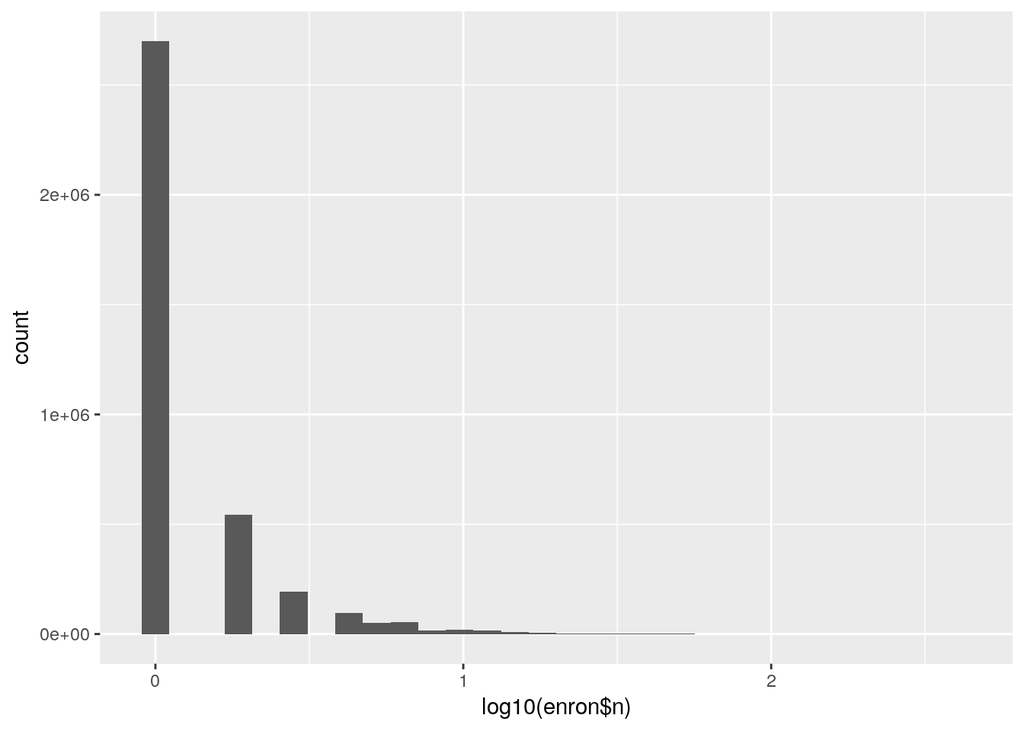

```r
qplot(log10(enron$n))
```

## Join

```r
enron2 <- left_join(enron %>% select(-n),
                    vocab,
                    by = c("word_id", "word_id"))
enron2[1:5,]
```

| doc_id | word_id | word |
| --- | --- | --- |
| 1 | 118 | access |
| 1 | 285 | additional |
| 1 | 1229 | april |
| 1 | 1688 | authorize |
| 1 | 2068 | basis |

```r
enron3 <- enron2 %>%
  select(doc_id, word) %>%
  group_by(doc_id) %>%
  summarise(doc = paste(word, collapse = " "), doc_length = length(word))
enron3[1:100,]
```

| doc_id | doc | doc_length |
| --- | --- | --- |
| 1 | access additional april authorize basis contract discharge doesnt expected fewer flow forecast half holtz imagination insight keith lower lowered note outflow panned power range site southern_californ… | 30 |
| 2 | able adjustment agreement alternatives appraisal areas austin balance based basis believe builder building class closer comfortable comment common comp component concern conference cost cover discuss … | 87 |
| 3 | action affair agreed agreement allen april attached authority bankruptcy belden benefit bev black bleeding bridge business_unit buying california cdwr christian communicate communicated contacting con… | 113 |
| 4 | america_corp apparently attached axis beginning chart comment constructed cover decreased demand fall fast file files fully illustrate increased late letter market mike north_america phillip prices ra… | 42 |
| 5 | addition additional agreeable approval builder clear construction contention contract cost definitely definition equivalent estimates fee fees finally gave george hard incidental included includes ins… | 59 |
| 6 | advantage america_corp answer asked attend august believe book comfortable concern discuss friday griffith heard hope issues manager managing mark meeting model month north_america open opportunity pl… | 36 |
| 7 | discount fine going idea letter look missed paper recommendation reference rent rentroll run sale special vacancies write | 17 |
| 8 | associate beginning category central commercial compare converting cuilla desk doubt duties end favorably handled hunter issues kuykendall manager martin promote regard similiar situation support tori | 25 |
| 9 | addictive anytime arcade classic exchange free game games greatest hooked kick needle offline operates play price quarter shockwavecom stick sure team thing thousand trap true video youre | 27 |
| 10 | accuracy create desk estimate goal held improve item list manager meeting position report reporting represent risk schedule top try underlying wednesday west | 22 |

[output cut: 90 more lines]

## Firmas

```r
set.seed(175904)
options("mc.cores" = 15L)
minhash <- minhash_generator(16, seed = 175904)
corpus <- TextReuseCorpus(text = enron3$doc,
                          tokenizer = tokenize_words,
                          lowercase = TRUE,
                          hash_func = minhash,
                          keep_tokens = TRUE,
                          keep_text = TRUE,
                          skip_short = FALSE)
```

Estos son los documentos similares

```r
mh <- hashes(corpus)
similitud <- sapply(mh, function(x) mean(mh[[900]]==x))

#listado de documentos
sims <- which(similitud > 0.5)
names(sims)
```

```
## [1] "doc-900"  "doc-1153" "doc-2325" "doc-2435"
```

Estas son las palabras, las cuales son similares efectivamente:

```r
print("Document 900")
```

```
## [1] "Document 900"
```

```r
corpus[[900]]$content
```

```
## address balance bill code consolidate cost credit creditor debt end equity estimated form free fuck full help helped hit home improve incurred interested invite late loan low lower message mind month monthly obligation party payment phone principal program property provide provided rating read re…
```

```r
print("Document 1153")
```

```
## [1] "Document 1153"
```

```r
corpus[[1153]]$content
```

```
## address balance bill code consolidate cost credit creditor debt end equity estimated form free fuck full help helped hit home improve incurred interested invite late loan low lower message mind monthly obligation party payment phone principal program property provide provided rating read reduce r…
```

```r
print("Document 2325")
```

```
## [1] "Document 2325"
```

```r
corpus[[2325]]$content
```

```
## address balance bill code consolidate cost credit creditor debt end equity estimated form free fuck full help helped hit home improve incurred interested invite late loan low lower message mind monthly obligation party payment phone principal program property provide provided rating read reduce r…
```

```r
print("Document 2435")
```

```
## [1] "Document 2435"
```

```r
corpus[[2435]]$content
```

```
## address balance bill code consolidate cost credit creditor debt end equity estimated form free fuck full help helped hit home improve incurred interested invite late loan low lower message mind monthly obligation party payment phone principal program property provide provided rating read reduce r…
```

```r
pairwise_compare(corpus[sims], jaccard_similarity, progress = F)
```

```
##          doc-900 doc-1153 doc-2325 doc-2435
## doc-900       NA        1        1        1
## doc-1153      NA       NA        1        1
## doc-2325      NA       NA       NA        1
## doc-2435      NA       NA       NA       NA
```

## LSH

```r
options("mc.cores" = 15L)
n_hashes <- 8
bands <- 2
docs_lsh <- c(100, 105, 1400)
minhashes <- minhash_generator(n_hashes, seed = 175904)
corpus_lsh <- TextReuseCorpus(
                text = enron3$doc,
                tokenizer = tokenize_words,
                minhash_func = minhashes,
                keep_tokens = T,
                keep_text = T,
                skip_short = FALSE)
lsh <- lsh(corpus_lsh, bands = bands, progress =  F)
lsh %>% sample_n(5)
```

| doc | buckets |
| --- | --- |
| doc-30533 | c2722c4df8a2ed12c9f99064a784a952 |
| doc-20175 | 477b3d464c49cd1d9280746f76343470 |
| doc-12709 | ec7fc0c517c8d3cb963cbd758047a03a |
| doc-8635 | 6641adf58bd31e81330afc7b14569720 |
| doc-20067 | c413ae689d11fd35856466d1583f7684 |

```r
lsh_100  <- lsh_query(lsh, "doc-100")
lsh_105  <- lsh_query(lsh, "doc-105")
lsh_1400 <- lsh_query(lsh, "doc-1400")
lsh_100; lsh_105; lsh_1400
```

| a | b |
| --- | --- |
| doc-100 | doc-11380 |
| doc-100 | doc-11397 |
| doc-100 | doc-11407 |
| doc-100 | doc-11626 |
| doc-100 | doc-21381 |
| doc-100 | doc-22035 |
| doc-100 | doc-36262 |
| doc-100 | doc-36396 |
| doc-100 | doc-4715 |
| doc-100 | doc-4743 |

[output cut: 6 more lines]

| a | b |
| --- | --- |

| a | b |
| --- | --- |

### Similitud de Jaccard

Estos son los datos exactos de las similitudes donde hay “doc-100”, como se muestra en el siguiente `pairwise_compare` no se hicieron discrimenaciones por similitud aparecen similitudes bajas.

```r
lsh_100_sims <- c(
  which(names(corpus_lsh) %in% lsh_100$a ),
  which(names(corpus_lsh) %in% lsh_100$b))
pairwise_compare(corpus_lsh[lsh_100_sims], jaccard_similarity)
```

```
##           doc-100  doc-4715  doc-4743  doc-4756  doc-4820  doc-4822
## doc-100        NA 0.2903226 0.2170543 0.2195122 0.2407407 0.2000000
## doc-4715       NA        NA 0.3135593 0.3333333 0.3750000 0.3008130
## doc-4743       NA        NA        NA 0.6818182 0.7422680 0.6416667
## doc-4756       NA        NA        NA        NA 0.8000000 0.6379310
## doc-4820       NA        NA        NA        NA        NA 0.7058824
## doc-4822       NA        NA        NA        NA        NA        NA
## doc-4883       NA        NA        NA        NA        NA        NA
## doc-5358       NA        NA        NA        NA        NA        NA
## doc-5418       NA        NA        NA        NA        NA        NA
## doc-11380      NA        NA        NA        NA        NA        NA
## doc-11397      NA        NA        NA        NA        NA        NA
## doc-11407      NA        NA        NA        NA        NA        NA
## doc-11626      NA        NA        NA        NA        NA        NA
## doc-21381      NA        NA        NA        NA        NA        NA
## doc-22035      NA        NA        NA        NA        NA        NA
## doc-36262      NA        NA        NA        NA        NA        NA
## doc-36396      NA        NA        NA        NA        NA        NA
##            doc-4883  doc-5358  doc-5418 doc-11380 doc-11397 doc-11407
## doc-100   0.2413793 0.2903226 0.2314050 0.2389381 0.2692308 0.2692308
## doc-4715  0.3653846 1.0000000 0.3486239 0.2432432 0.2621359 0.2621359
## doc-4743  0.6886792 0.3135593 0.6727273 0.1904762 0.2014388 0.2014388
## doc-4756  0.7551020 0.3333333 0.7184466 0.2000000 0.2030075 0.2030075
## doc-4820  0.8571429 0.3750000 0.8089888 0.2063492 0.2203390 0.2203390
## doc-4822  0.8039216 0.3008130 0.8529412 0.1688312 0.1780822 0.1780822
## doc-4883         NA 0.3653846 0.9431818 0.2000000 0.2125984 0.2125984
## doc-5358         NA        NA 0.3486239 0.2432432 0.2621359 0.2621359
## doc-5418         NA        NA        NA 0.1928571 0.2045455 0.2045455
## doc-11380        NA        NA        NA        NA 0.7241379 0.7241379
## doc-11397        NA        NA        NA        NA        NA 1.0000000
## doc-11407        NA        NA        NA        NA        NA        NA
## doc-11626        NA        NA        NA        NA        NA        NA
## doc-21381        NA        NA        NA        NA        NA        NA
## doc-22035        NA        NA        NA        NA        NA        NA
## doc-36262        NA        NA        NA        NA        NA        NA
## doc-36396        NA        NA        NA        NA        NA        NA
##           doc-11626 doc-21381 doc-22035 doc-36262 doc-36396
## doc-100   0.2727273 0.3250000 0.2321429 0.3291139 0.3209877
## doc-4715  0.2783505 0.3506494 0.2592593 0.3376623 0.3291139
## doc-4743  0.2105263 0.2368421 0.1849315 0.2612613 0.2566372
## doc-4756  0.2125984 0.2523364 0.2388060 0.2547170 0.2500000
## doc-4820  0.2321429 0.2826087 0.2096774 0.2857143 0.2795699
## doc-4822  0.1857143 0.2166667 0.1710526 0.2393162 0.2352941
## doc-4883  0.2231405 0.2673267 0.2030075 0.2700000 0.2647059
## doc-5358  0.2783505 0.3506494 0.2592593 0.3376623 0.3291139
## doc-5418  0.2142857 0.2547170 0.1956522 0.2692308 0.2641509
## doc-11380 0.7777778 0.2783505 0.2000000 0.2424242 0.2376238
## doc-11397 0.9154930 0.3033708 0.2131148 0.2637363 0.2580645
## doc-11407 0.9154930 0.3033708 0.2131148 0.2637363 0.2580645
## doc-11626        NA 0.3253012 0.2241379 0.2823529 0.2758621
## doc-21381        NA        NA 0.2842105 0.4354839 0.4218750
## doc-22035        NA        NA        NA 0.2736842 0.2680412
## doc-36262        NA        NA        NA        NA 0.9565217
## doc-36396        NA        NA        NA        NA        NA
```

### Textos

```r
sapply(lsh_100_sims, function(i){
  sprintf('doc-%d: %s', i, corpus_lsh[[i]]$content)
       })
```

```
##  [1] "doc-100: acceptance according affiliate affiliates afternoon andor approval attorney basis binding board closing contract convenient corp create deal enforceable estoppel evidence exchange finalized going hear jacques jeff kevin kolb kuos mail material message money offer party person phill…
##  [2] "doc-4715: acceptance affiliate affiliates andor arrange arranged bachelor basis binding blow buffet chosen contract copies corp correct create cruise dinner enforceable estoppel evidence final freeport future gambling gourmet jan jason leave material meeting message money offer paid party p…
##  [3] "doc-4743: able acceptance affiliate affiliates andor arrangement asap ask bachelor basis bass binding brethren brother buffet calculation called choice contract copies corp cost create cruise definitely delay dinner drink enforceable eric estoppel evidence expenses fallen feb festivities fi…
##  [4] "doc-4756: acceptance affiliate affiliates andor arrangement asap attend bachelor basis bass binding brethren brother buffet calculation called choice contract copies corp cost crap create cruise dad date dinner download drink enforceable estoppel evidence expenses explorer fallen feb festiv…
##  [5] "doc-4820: acceptance affiliate affiliates andor arrangement asap bachelor basis bass binding brethren brother buffet calculation called choice contract copies corp cost create cruise delete dinner drink enforceable estoppel evidence expenses fallen feb festivities finally freeport gambling …
##  [6] "doc-4822: acceptance affiliate affiliates andor arrangement asap bachelor basis bass binding brethren brother buffet calculation called choice complicated contract copies corp cost count create cruise dad decide designated dinner drink driver driving early enforceable eric estoppel evidence…
##  [7] "doc-4883: acceptance affiliate affiliates andor arrangement asap bachelor basis bass binding brethren brother buffet calculation called choice contract copies corp cost count create cruise dad designated dinner drink driver enforceable estoppel evidence expenses fallen feb festivities final…
##  [8] "doc-5358: acceptance affiliate affiliates andor arrange arranged bachelor basis binding blow buffet chosen contract copies corp correct create cruise dinner enforceable estoppel evidence final freeport future gambling gourmet jan jason leave material meeting message money offer paid party p…
##  [9] "doc-5418: acceptance affiliate affiliates andor arrangement asap bachelor basis bass binding brethren brother buffet calculation called choice contract copies corp cost count create cruise dad designated dinner drink driver enforceable estoppel evidence expenses fallen feb festivities final…
## [10] "doc-11380: able acceptance addition address addresses affiliate affiliates andor basis binding confirm confusion contract corp correct create cycle del diff enforceable enroncom estoppel evidence forward grid group internal internally likely limit limited list load material mercaldo multipl…
## [11] "doc-11397: able acceptance addition address addresses affiliate affiliates andor answer basis binding buchanan confirm contract corp correct create cycle del diff enforceable enroncom estoppel evidence forward function getting grid group internal karen likely limit list managed material mer…
## [12] "doc-11407: able acceptance addition address addresses affiliate affiliates andor answer basis binding buchanan confirm contract corp correct create cycle del diff enforceable enroncom estoppel evidence forward function getting grid group internal karen likely limit list managed material mer…
## [13] "doc-11626: able acceptance addition address addresses affiliate affiliates andor basis binding confirm contract corp correct create cycle del diff enforceable enroncom estoppel evidence forward getting grid group internal likely limit list material mercaldo mistaken nom non notice number of…
## [14] "doc-21381: acceptance affiliate affiliates andor associates audrey basis binding cash cell contract copies corp create cullen davis diana enforceable estoppel evidence experience fax market material message number offer party person prohibited property receive relevant relied reply review s…
## [15] "doc-22035: acceptance addressee advise affiliate affiliates andor ass basis binding bitch bought btw business case conclusion confidentiality consent contained contract copies copy corp create dale date deliver delivery destroy download employer endorsed enforceable estoppel evidence explor…
## [16] "doc-36262: acceptance affiliate affiliates andor ask basis binding clint contract copies corp create dean didnt enforceable estoppel evidence friend hey julies material meet message met october offer party past person prohibited property receive relevant relied review sole sound strictly ta…
## [17] "doc-36396: acceptance affiliate affiliates andor ask basis binding clint contract copies corp create dean didnt enforceable estoppel evidence friend hey julies material meet message met michelle october offer party past person prohibited property receive relevant relied review schultz sole …
```

## Examen

1. Construye una matriz de firmas (de longitud 16) de minhashing para esta colección. Utiliza la matriz de firmas para encontrar mails similares al 900 (más de 50% de similitud de Jaccard) ¿Qué palabras comparten estos documentos?

2. (LSH) Utiliza 8 bandas de 2 hashes cada una para obtener pares candidatos para similitud. A partir de los candidatos en las cubetas correspondientes, devuelve los 20 mejores candidatos (si existen) para los documentos 100, 105, 1400. Recuerda calcular la similitud exacta para los pares candidatos que consideres.

3. En cada caso, describe el grupo de candidatos mostrando las palabras más comunes que ocurren en ellos.